# Data Translation Challenge

Author

Sri Lakshmi

# Amazon Sales of technology products in 2019

## Audience:

Amazon’s tech products division managers who want ideas for increasing revenues.

## About Dataset:

The data covers the amazon sales of 19 different technology products in urban areas of ten cities from 8 states for the period January 1st, 2019, through January 1st, 2020. However, I am interested in the Sales analysis of 2019 data, hence considering only sales placed throughout 2019.

**List of Technology products included in the dataset:**

| 20in Monitor | Bose SoundSport Headphones | Macbook Pro Laptop | LG Dryer |
| --- | --- | --- | --- |
| 27in 4K Gaming Monitor | Apple Airpods Headphones | ThinkPad Laptop | LG Washing Machine |
| 27in FHD Monitor | Wired Headphones | Iphone | AA Batteries(4pack) |
| 34in Ultrawide Monitor | USB-C Charging Cable | Google Phone | AAA Batteries(4pack) |
| Flatscreen TV | Lightning Charging Cable | Vareebadd Phone |  |

**List of Urban areas included in the dataset:**

| San Francisco, CA 94016 | Dallas, TX 75001 |
| --- | --- |
| Los Angeles, CA 90001 | Austin, TX 73301 |
| New York City, NY 10001 | Portland, OR 97035 |
| Boston, MA 02215 | Seattle, WA 98101 |
| Atlanta, GA 30301 | Portland, ME 04101 |

## Sales Analysis reveals that December is the best month for the listed tech products sales in 2019

Visualizing the sales performance over time by month to identify the seasonal patterns and trends in sales. This also helps compare sales performance by month to determine which month had the highest sales in 2019.

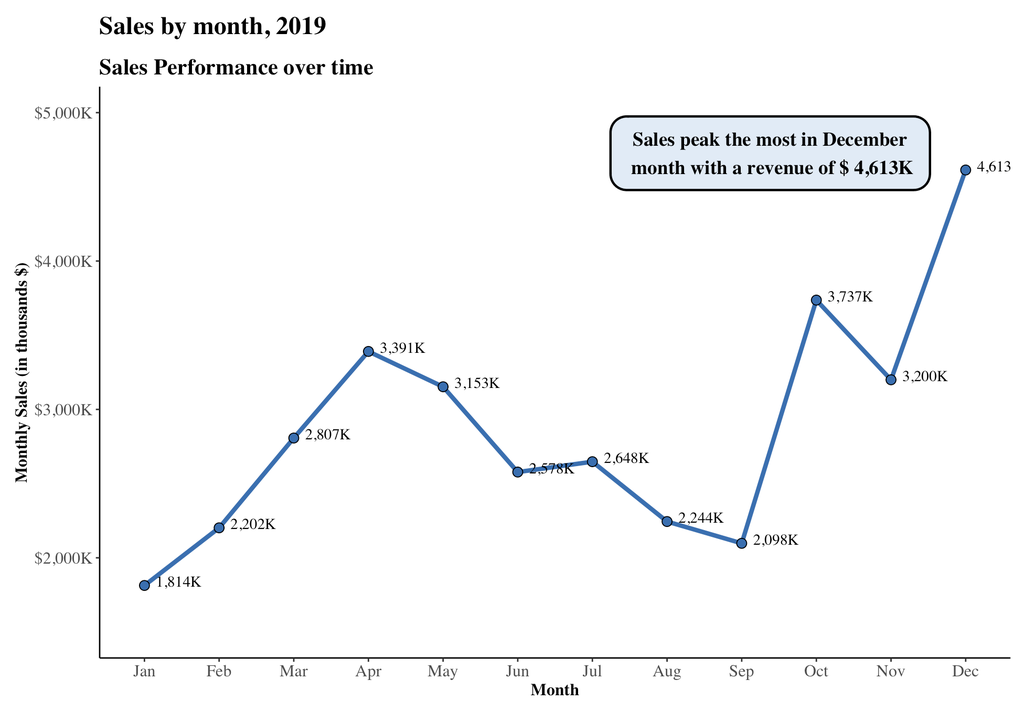

The above visualization shows that the highest tech product sales were recorded in December with a revenue of approx. $4,613K followed by October month with a revenue of approx. $3,737K, indicating that the holiday season is a critical time for the business. Hence, I recommend providing more discounts and offers on tech products during the holiday season, further boosting sales.

## Sales Analysis reveals that San Francisco, CA 94016 area had the highest Revenue Contribution in 2019

Visualizing the sales distribution by location (zip code) to identify which products are famous in which urban areas that can be used to inform regional marketing efforts.

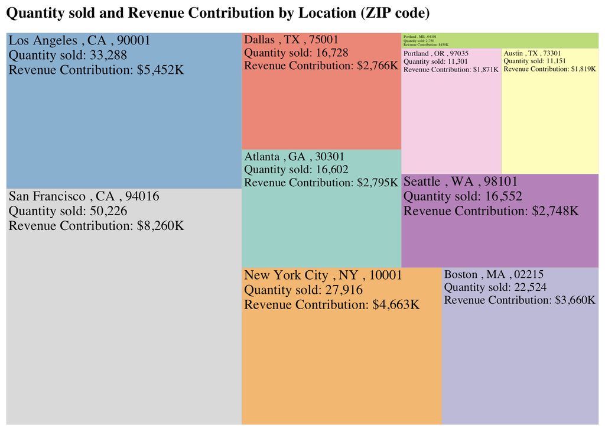

The above visualization shows that the urban area with zip code 94016 in San Francisco, CA contributed the highest revenue of approx. $8,260K to the company with the highest quantity sold, indicating that it is a significant market for the company. In contrast, the urban area with zip code 04101 in Portland, ME, contributed the most negligible revenue of approx. $450K with the least quantity sold. Hence, I recommend targeting marketing efforts in the Portland, ME 04101 area will increase the sales and its revenue contribution to the company.

## Relationship between the Revenue Price of each product in the data shows a strong positive correlation in 2019

Visualizing the relationship between the revenue and price of each product to identify any trends or patterns in how changes in cost per unit affect product sales.

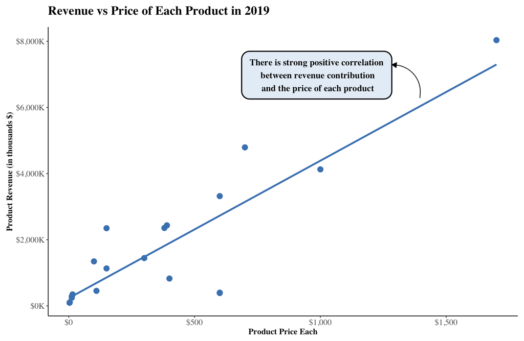

The above visualization shows a strong positive correlation between the price of each product and its revenue contribution. The higher the product price, the higher its revenue contribution to the company.

## Sales Order Analysis by the time of the day in 2019 reveals that 7 PM is the best time to display product advertisements

Visualizing the number of orders placed by the time of the day in the hour to identify when most orders were placed in 2019 to display product advertisements. Knowing the best time to advertise can help the company to reach more customers and increase sales.

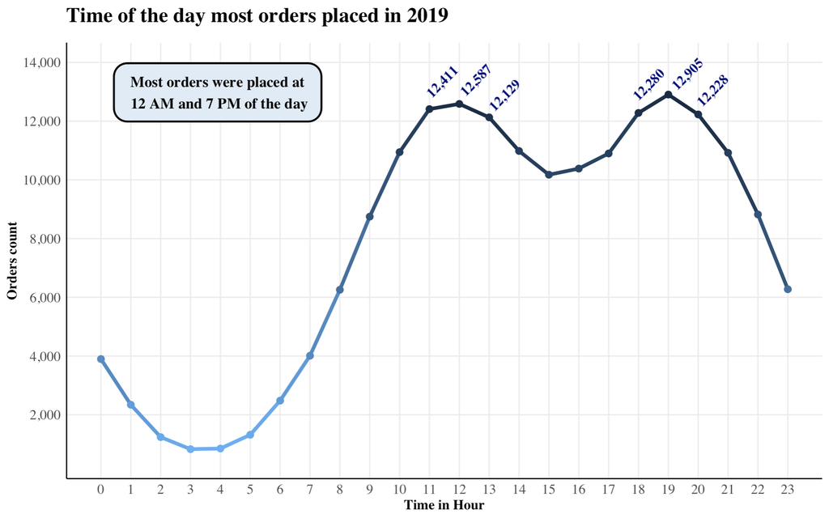

The above visualization shows that most orders were placed at 7 PM of the day, followed by noon of the day. Hence, the best time to roll out the advertisement campaign is between 11 AM and 12 AM, and again between 6 PM to 7 PM of the day to maximize the likelihood of product sales.

## Sales Analysis reveals that the best-selling product combination is iPhone and Lightning Charging cable compared to others in 2019

Visualizing the products most commonly bought together to identify the cross-selling opportunities, like promoting them as a bundle or package deal, encourages customers to buy more products than initially intended, increasing the overall order value and revenue. Offering product combinations commonly purchased together can also improve the customer experience, which can help build brand loyalty and drive repeat business.

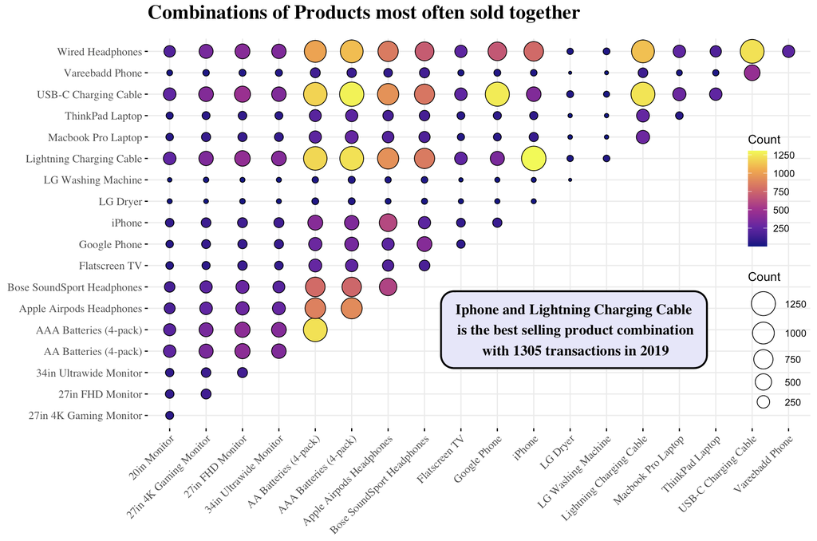

The above visualization shows that iPhone and Lightning charging cables are most commonly bought together with 1305 transactions, followed by Google phone and USB-C Charging cables with 1256 transactions, highlighting the importance of offering products that complement each other. Hence, I recommend promoting these product combinations as a bundle or package deal to attract customers.

## Sales Analysis reveals that the Macbook Pro laptop has the highest Revenue Contribution than other listed tech products in 2019

Visualizing the revenue contributed by each product in the dataset to identify the products which contributed the highest and most negligible revenue to the company in 2019, which could inform decisions about pricing, product development and marketing strategies like discontinuing products that are not selling well or expanding the product line to include similar items of products with the highest revenue.

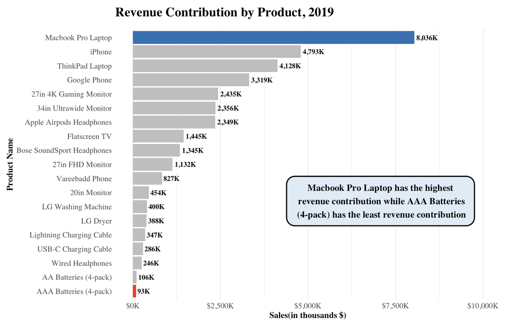

The above visualization shows that the Macbook Pro laptops generate the most revenue for the company and AAA Batteries (4-pack) have the lowest revenue contribution.

## Relationship between the top-selling products in the data and their price reveals a strong negative correlation in 2019

Visualizing the total quantity sold for each product in the dataset to identify which products are the most popular and profitable and their relationship with price.

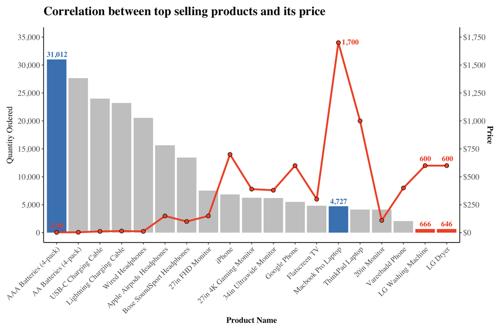

The top-selling products correlate strongly with their product price. The cheaper the product higher the quantity ordered, and vice versa. The above visualization shows that AAA Batteries (4-pack) have the highest quantity ordered with a price of $ 2.99, suggesting that the company could benefit from increasing its production, and LG washing machines & LG dryers have the least quantity ordered with a price of $ 600, indicating that company may need to lower the price to stimulate demand. However, we saw that Macbook pro laptop has the highest revenue with a price of $ 1,700 from the previous visualization.

## Sales Analysis by Day and Product in 2019 reveals that Macbook pro laptop is the most popular product with the most sales on Tuesdays

Visualizing the sales by day and product to identify which products are selling well on which days and ensure that popular products are always in stock, reducing the risk of stockouts and lost sales. This also helps to identify the underperforming days, and the company can adjust its pricing or promotions to encourage sales during these periods, which helps to increase revenue.

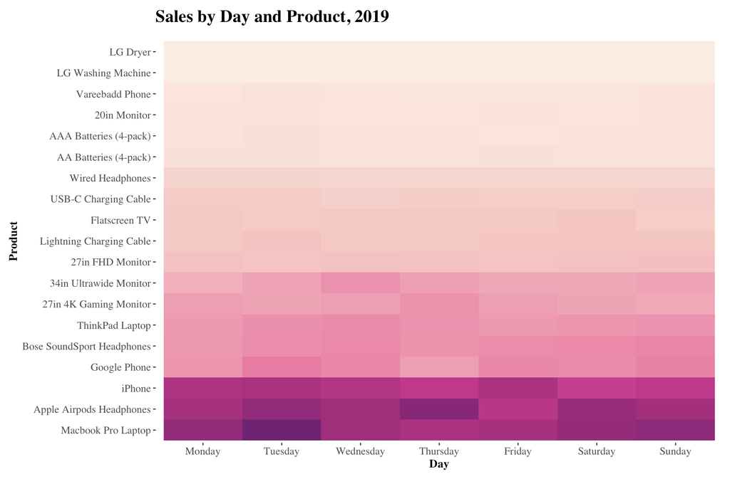

The above visualization shows that Macbook Pro Laptop is the most popular product selling well on Tuesdays and least sold on Thursdays. Hence, I recommend promoting the Macbook Pro laptop on Thursdays by adjusting its price or organizing sales events to attract more customers.

## Conclusion:

Overall, the above visualizations provide valuable insights that can help the company to make informed decisions about its product development, marketing strategies, and inventory management, which can ultimately lead to increased revenue and growth.